# Biometrie onderzoek

2024-04-26

## Inleiding

Voor dit onderzoek is de breedte en lengte van de handen van 40 mensen, mannen en vrouwen opgemeten.

Het doel is om vast te stellen of er een verschil is tussen de grootte van de hand van mannen en vrouwen.

De onderzoeksvraag is dan: Is er bij de mens een sexe verschil in de lengte/breedte ratio van de hand?

De nulhypothese is: Er is bij de mens geen sexe verschil in de lengte/breedte ratio van de hand

Het staat je vrij een ander simpel te meten biometrisch kenmerk te onderzoeken. Voorwaarde is wel dat je twee aspecten meet (bv lichaamslengte en hoofdomtrek) en hun relatie onderzoekt, en ook dat je verschillende groepen onderzoekt (man/vrouw, jong/oud etc.). Ten slotte moeten verschillende studenten het meetwerk afwisselen en ook dat moet vastgelegd worden.

## HYPOTHESE:

Er is bij de mens een sexeverschil in de lengte/breedte ratio van de hand.

NULHYPOTHESE: Er is bij de mens geen sexeverschil in de lengte/breedte ratio van de hand.

### Ontwerp van het experiment

Van 40 proefpersonen, gelijk verdeeld over mannen en vrouwen en willekeurig geselecteerd in en rond het schoolgebouw, zal de sexe gevraagd worden en vervolgens de handlengte en -breedte gemeten worden.

#### Protocol voor meting handlengte en handbreedte

##### Benodigdheden

1. Maatlat, schuifmaat of meetlint.
2. Spreadsheet om resultaten vast te leggen, met toegang hiertoe op locaties zonder internet-toegang.
3. Je laborant-ID: een unieke *identifier* die jou als onderzoeker identificeert. Neem hiervoor de laatste 4 cijfers van je studentnummer.

##### Data verzamelen

Zoek, samen met een ander groepje van je klas, in of rond het schoolgebouw medestudenten. Vraag beleefd of ze willen participeren in een klein wetenschappelijk onderzoekje voor school waarbij de maten van de hand opgenomen zullen worden.  
Is het antwoord nee, dan groet je vriendelijk en zoek je verder.  
Is het antwoord ja, dan vraag je of de proefpersoon de hand horizontaal en gestrekt wil houden met de palm naar beneden. Vervolgens meet je zowel de lengte als de breedte van de hand op, in millimeters. Deze leg je vast in de spreadsheet, samen met je laborant-ID en een identifier (géén naam!) van de proefpersoon. Ten slotte vraag je aan de proefpersoon zijn/haar/hun sexe en legt deze vast. Wil de proefpersoon deze niet geven, of is die nonbinair, dan leg je dit vast als “anders/onbekend”. Het “parallel groepje” (dat niet jouw bevindingen mag horen) doet dezelfde meting en slaat deze met dezelfde participant identifier op.  
Bedank de proefpersoon voor deelname.  
Wissel de metingen af tussen de verschillende studenten in jouw groepje.

Ga door totdat van voldoende proefpersonen de gegevens zijn verzameld.

## Uitvoering

Je moet de onderzoeksresultaten in deze vorm opslaan:

```
laborant_ID,subject_ID,handlengte,handbreedte,sexe
3241,G1_03,113,104,m
```

## Analyse

### Lees je eigen data in

Om data vanuit een tekstbestand in te lezen kan je dit codeblok gebruiken, aannemend dat je data er exact zo uitzien als in bovenstaande voorbeeld:

```r
data_file <- "Verzamelde_hand_data.csv"

#data format: laborant_ID,subject_ID,handlengte,handbreedte,sexe
biometric_data <- read.table(file = data_file,
                        header = TRUE,
                        sep = ",")
```

Let op: als je missende data hebt moet je die specificeren door dit argument toe te voegen: `na.strings = "<jouw NA symbool>"`

### Beschrijvende statistiek

LAAT ENKELE BESCHRIJVENDE STATISTISCHE WAARDES ZIEN. GEEF EEN OF MEERDERE BOXPLOTS EN HISTOGRAMMEN BESPREEK DEZE DATA EN FIGUREN KORT. KAN JE IETS ZEGGEN OVER DE DATAVERDELING?

```r
biometric_data$ratio <- biometric_data$handlengte / biometric_data$handbreedte
head(biometric_data)
```

```
##   laborant_ID subject_ID handlengte handbreedte sexe    ratio
## 1      0674_q          1       17.6         9.1    m 1.934066
## 2      5059_r          1       17.0         8.9    m 1.910112
## 3      0674_q          2       16.6         9.2    m 1.804348
## 4      5059_r          2       16.5         8.6    m 1.918605
## 5      0674_q          3       18.2         9.0    m 2.022222
## 6      5059_r          3       18.0         8.5    m 2.117647
```

```r
gemiddelde_vrouwen <- mean(biometric_data[biometric_data$sexe == "v" , "handlengte"]) # vrouwen
cat(gemiddelde_vrouwen, "cm gemiddelde handlengte vrouwen")
```

```
## 16.90938 cm gemiddelde handlengte vrouwen
```

```r
gemiddelde_mannen <- mean(biometric_data[biometric_data$sexe == "m" , "handlengte"]) # mannen
cat(gemiddelde_mannen, "cm gemiddelde handlengte mannen")
```

```
## 18.16875 cm gemiddelde handlengte mannen
```

```r
tapply(X = biometric_data$handlengte, # split wat
       INDEX = biometric_data$sexe,  # split op
       FUN = mean)
```

```
##        m        v
## 18.16875 16.90938
```

```r
#split over gender into list of dataframes
gender_split_data <- split(x = biometric_data,
      f = biometric_data$sexe)

#apply a function to report means of both measurements
sapply(X = gender_split_data,
       FUN = function(x){
           c(handlengte = mean(x$handlengte),
             handbreedte = mean(x$handbreedte),
             ratio = mean(x$ratio))
       })
```

```
##                     m         v
## handlengte  18.168750 16.909375
## handbreedte  8.972917  8.387500
## ratio        2.042161  2.033157
```

### Welke verdeling?

Hoe kleiner de steekproefgrootte (*sample size*) hoe lastiger het is de onderliggende verdeling vast te stellen. Speel maar eens met dit blokje code, en verander de steekproefgrootte (`n=`) in de `rnorm()` functie en de `breaks=` in de `hist()` functie. Neem voor *n* bijvoorbeeld achtereenvolgens 10, 100, 1000, 10000, 10000 en voor *breaks* 5, 10, 50. Wanneer zie je een echte normaalverdeling verschijnen?

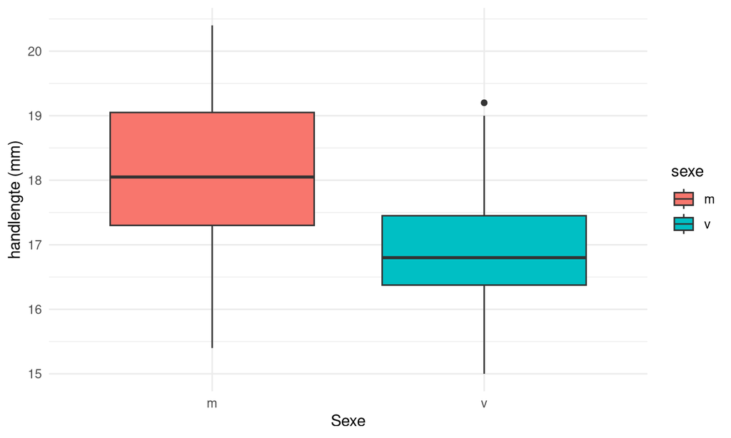

```r
library(ggplot2)
# maak de plot en voeg lagen toe
ggplot(data = biometric_data,
       mapping = aes(x = sexe, y = handlengte, fill = sexe)) +
    geom_boxplot() +                            # boxplot visualisatie
    labs(x = "Sexe", y = "handlengte (mm)") +  # as-labels
    theme_minimal()                             # beetje schoner plotje maken
```

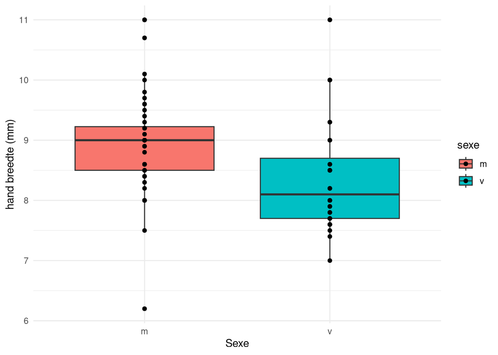

```r
ggplot(data = biometric_data,
       mapping = aes(x = sexe, y = handbreedte, fill = sexe)) +
    geom_boxplot() +                            # boxplot visualisatie
    geom_point() +                              # met punten erbij
    labs(x = "Sexe", y = "hand breedte (mm)") + # as-labels
    theme_minimal()                             # beetje schoner plotje maken
```

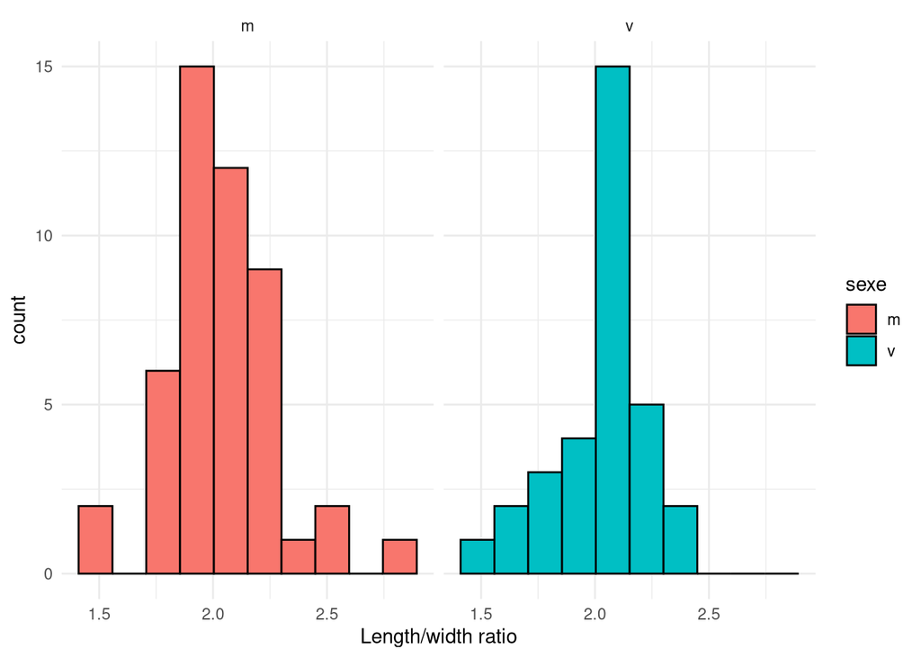

```r
ggplot(data = biometric_data,
       mapping = aes(x = ratio, fill = sexe)) +
    geom_histogram(bins = 10, colour = "black") + # histogram layer with 10 bins
    facet_wrap(. ~ sexe) +                       # split plots over gender
    labs(x = "Length/width ratio") +
    theme_minimal()
```

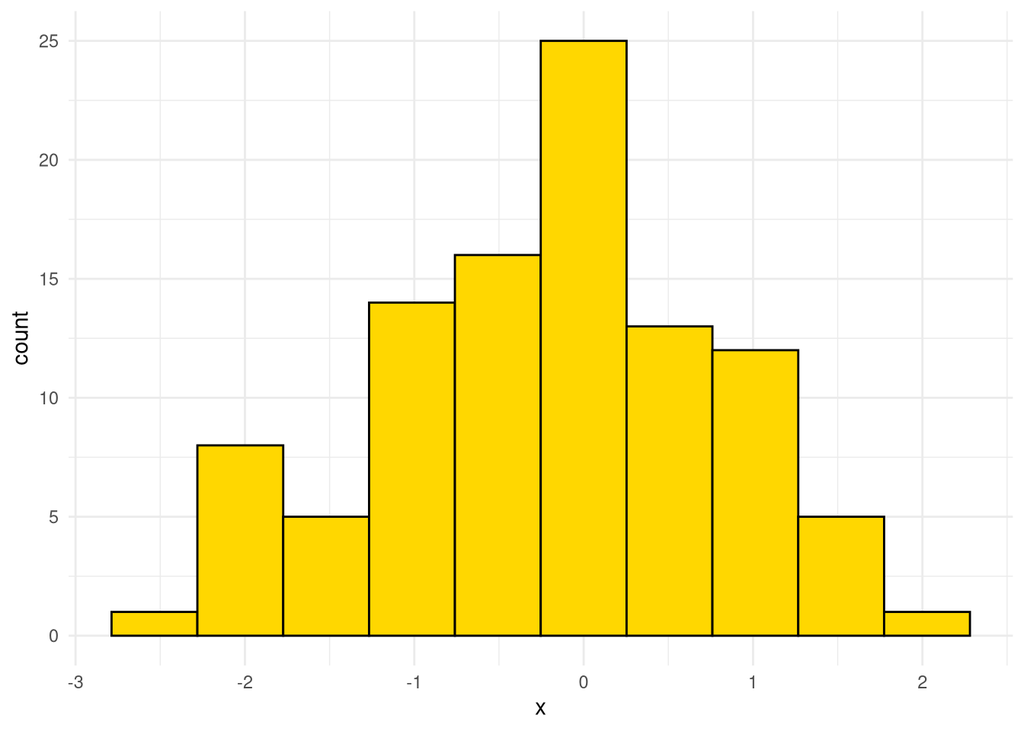

```r
hist_data <- data.frame(x = rnorm(n = 100))
ggplot(data = hist_data,
       mapping = aes(x = x)) +
    geom_histogram(bins = 10, fill = "gold", colour = "black") +
    theme_minimal()
```

**Dit *experiment* met de argumenten van `rnorm()` en `hist()` moet je opnemen in je eigen RMarkdown.**  
Beantwoord deze vragen:

1. Wat gebeurt er met de vorm van de verdeling als `n` groter wordt?  
   Het begint meer op een normaalcurve te lijken.
2. Wat gebeurt er met de spreiding van de data (x-as) als `n` groter wordt, en kan je dat verklaren?  
   De spreiding wordt groter omdat er meer waarden zijn is de kans ook groter dat er hogere of lagere waarden zijn dan wanneer het er maar een paar zijn.
3. Waarom is bij zelfde instellingen voor `n` en `breaks` de uitkomst toch verschillend?
4. Welke minimale `n` geeft het meeste kans om een echte normaalverdeling te zien?  
   Bij n = 1000.
5. Wat voor bijzonders is er aan de hand met het `breaks` argument? Geeft de documentatie daar een verklaring voor?  
   Als met “breaks” bins bedoeld wordt: hiermee wordt het histogram in staven verdeeld, hoe hoger het bins nummer, hoe meer staven.  
   Wanneer er geen “bins” argument mee wordt gegeven kiest R zelf met behulp van een algorithme (ook door de gebruiker te kiezen) hoeveel bins er gemaakt moeten worden.

### Bronnen van variatie

De variatie tussen de handafmetingen van mannen en vrouwen noemen we biologische variatie. Alles in de biologie kent variatie, door milieu of door genetica. Echter, als je in een experiment dingen meet doet een persoon dat en gebruik je meestal instrumenten. Dat noemen we experimentele variatie. Twee meetlatten kunnen net anders gefabriceerd worden, en een onderlinge -maar dan reproduceerbare afwijking hebben ten opzichte van elkaar. Aan de andere kant kan het zijn dat twee laboranten experimenten net op een verschillende manier uitvoeren. Deze laatste bron van variatie gaan we hier onderzoeken.

Onderstaande boxplot geeft de meetwaarden voor handlengte uitgesplitst op laborant_ID.

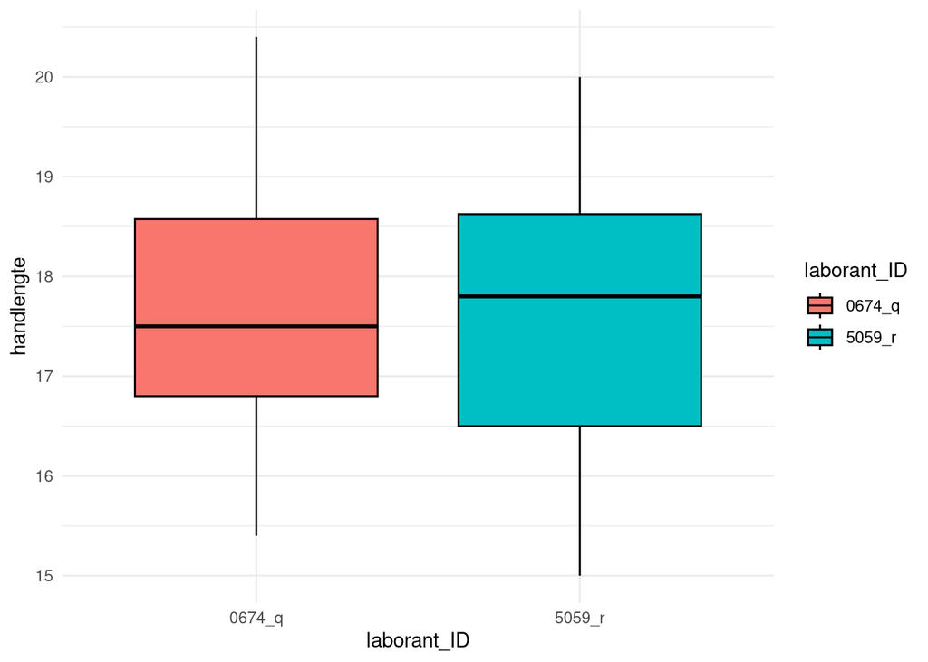

```r
ggplot(data = biometric_data,
       mapping = aes(x = laborant_ID, y = handlengte, fill = laborant_ID)) +
    geom_boxplot(colour = "black") +
    theme_minimal()
```

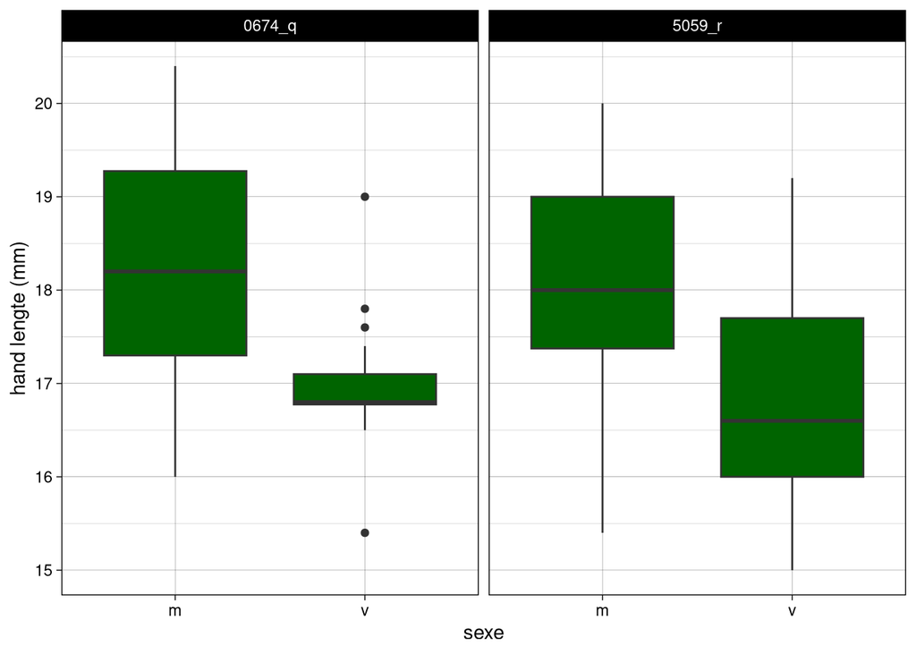

```r
ggplot(data = biometric_data,
       mapping = aes(x = sexe, y = handlengte)) +
    geom_boxplot(fill = "darkgreen") +
    facet_wrap(. ~ laborant_ID) +
    ylab("hand lengte (mm)") +
    theme_linedraw()
```

### De hypothese aannemen?

VOER RELEVANTE STATISTISCHE TESTS UIT

```r
shapiro.test(biometric_data$ratio)
```

```
##
##  Shapiro-Wilk normality test
##
## data:  biometric_data$ratio
## W = 0.97434, p-value = 0.1075
```

De p-waarde is niet kleiner dan 0.05 dus is er geen sprake van een significant verschil van de normale verdeling.

```r
female_ratios <- subset(biometric_data,
                        subset = sexe == "v",
                        select = ratio,
                        drop = T) # drop = T forces ro a vector
male_ratios <- subset(biometric_data,
                        subset = sexe == "m",
                        select = ratio,
                        drop = T)
t.test(female_ratios, male_ratios)
```

```
##
##  Welch Two Sample t-test
##
## data:  female_ratios and male_ratios
## t = -0.18873, df = 74.195, p-value = 0.8508
## alternative hypothesis: true difference in means is not equal to 0
## 95 percent confidence interval:
##  -0.10405886  0.08605102
## sample estimates:
## mean of x mean of y
##  2.033157  2.042161
```

Omdat de p-waarde weer hoger is dan 0.05 kan de nulhypothese niet verworpen worden.

```r
wilcox.test(female_ratios, male_ratios)
```

```
##
##  Wilcoxon rank sum test with continuity correction
##
## data:  female_ratios and male_ratios
## W = 798.5, p-value = 0.7683
## alternative hypothesis: true location shift is not equal to 0
```

## Reflectie op het experiment

#### Wat je moet inleveren

Voor de verwerking en analyse van je eigen data maak je gebruik van het aangeleverde template RMarkdown document. Daarin doorloop je dezelfde onderzoek stappen als hieronder, maar dan met je eigen data. Aan het einde van de dag gaat dat document, in originele en “geknitte” vorm, samen met je databestand, in een git repo die is opgezet volgens voorschrift in de cursushandleiding. De link hiernaar toe gaat in je portfolio op eJournal. Let op dat je *alle* stappen hebt doorlopen voordat je inlevert. Gebruik ook de RStudio spellingscontrole!  
Vergeet niet jullie namen en studentnummers bovenaan de markdown te zetten!